# 1.Business problem:

### Precision-Recall curve

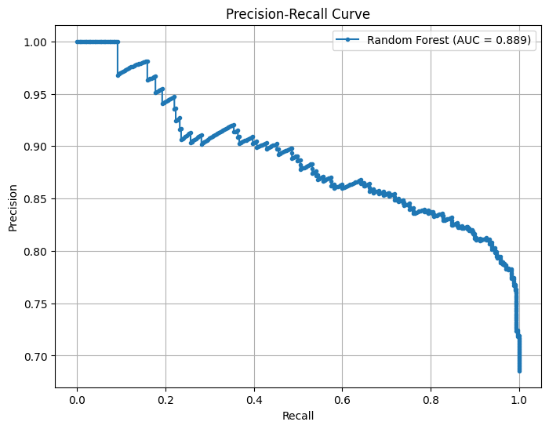

```python
# Get predicted probabilities for the positive class (1)
Y_test_probs_onehot_sm_rf = best_model_onehot_sm_rf.predict_proba(X_test_onehot)[:, 1]

# Compute precision-recall curve
precision, recall, _ = precision_recall_curve(Y_test_onehot, Y_test_probs_onehot_sm_rf)

# Compute area under the curve (AUC-PR)
pr_auc = auc(recall, precision)

# Plot Precision-Recall curve
plt.figure(figsize=(8, 6))
plt.plot(recall, precision, marker='.', label=f'Random Forest (AUC = {pr_auc:.3f})')
plt.xlabel('Recall')
plt.ylabel('Precision')
plt.title('Precision-Recall Curve')
plt.legend()
plt.grid()
plt.show()
```

Observations:

The Random Forest model achieves an AUC of 0.889, indicating strong predictive power, but as recall increases, precision drops, suggesting a trade-off where capturing more resigning drivers comes at the cost of more false positives.

### ROC-AUC curve

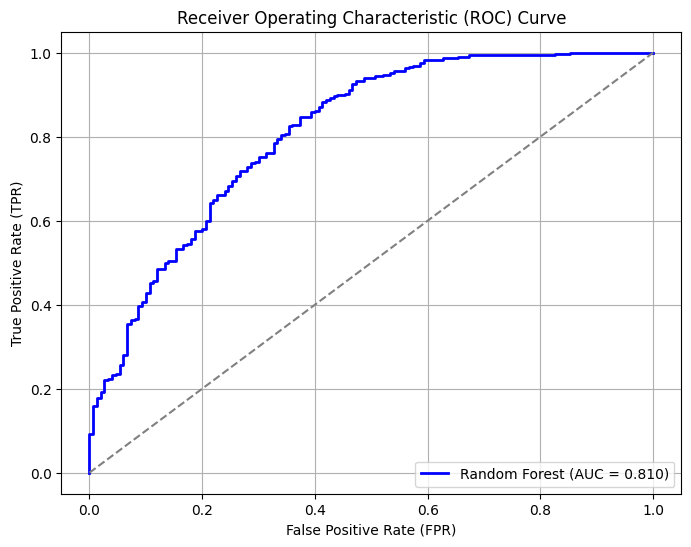

```python
# Compute ROC curve
fpr, tpr, _ = roc_curve(Y_test_onehot, Y_test_probs_onehot_sm_rf)

# Compute AUC (Area Under Curve)
roc_auc = auc(fpr, tpr)

# Plot ROC curve
plt.figure(figsize=(8, 6))
plt.plot(fpr, tpr, color='blue', lw=2, label=f'Random Forest (AUC = {roc_auc:.3f})')
plt.plot([0, 1], [0, 1], color='gray', linestyle='--')  # Diagonal line (random model)
plt.xlabel('False Positive Rate (FPR)')
plt.ylabel('True Positive Rate (TPR)')
plt.title('Receiver Operating Characteristic (ROC) Curve')
plt.legend(loc='lower right')
plt.grid()
plt.show()
```

The Random Forest model achieves an AUC of 0.810, showing good discrimination between drivers who will leave and those who won’t.

## Boosting

```python
xgb = XGBClassifier(use_label_encoder=False, eval_metric='logloss', random_state=42)

pipeline_xgb = Pipeline([
    ('scaler', preprocessor),  # Standardization
    ('classifier', xgb)  # XGBoost Classifier
])

param_dist_xgb = {
    'classifier__n_estimators': [50, 100, 200, 500],  # Number of trees
    'classifier__max_depth': [3, 5, 10, 15],
    'classifier__learning_rate': [0.01, 0.05, 0.1, 0.2],
    'classifier__subsample': [0.6, 0.8, 1.0],
    'classifier__colsample_bytree': [0.6, 0.8, 1.0],
    'classifier__gamma': [0, 0.1, 0.2, 0.3],
    'classifier__min_child_weight': [1, 3, 5]
}
```

```python
random_search_label_encoded_sm_xgb = RandomizedSearchCV(
    pipeline_xgb, param_distributions=param_dist_xgb,
    cv=cv, scoring='f1',
    n_iter=20, random_state=42, n_jobs=-1
)

# Fit the model
random_search_label_encoded_sm_xgb.fit(X_train_label_encoded_sm, y_train_label_encoded_sm)

# Print best parameters and score
print("Best Parameters:", random_search_label_encoded_sm_xgb.best_params_)
print("Best Score:", random_search_label_encoded_sm_xgb.best_score_)
```

```
Best Parameters: {'classifier__subsample': 0.8, 'classifier__n_estimators': 500, 'classifier__min_child_weight': 1, 'classifier__max_depth': 15, 'classifier__learning_rate': 0.2, 'classifier__gamma': 0.1, 'classifier__colsample_bytree': 1.0}
Best Score: 0.8129564472438211
```

```python
random_search_onehot_sm_xgb = RandomizedSearchCV(
    pipeline_xgb, param_distributions=param_dist_xgb,
    cv=cv, scoring='f1',
    n_iter=20, random_state=42, n_jobs=-1
)

# Fit the model
random_search_onehot_sm_xgb.fit(X_train_onehot_sm, y_train_onehot_sm)

# Print best parameters and score
print("Best Parameters:", random_search_onehot_sm_xgb.best_params_)
print("Best Score:", random_search_onehot_sm_xgb.best_score_)
```

```
Best Parameters: {'classifier__subsample': 0.8, 'classifier__n_estimators': 500, 'classifier__min_child_weight': 5, 'classifier__max_depth': 3, 'classifier__learning_rate': 0.2, 'classifier__gamma': 0, 'classifier__colsample_bytree': 0.6}
Best Score: 0.8351625184424559
```

```python
random_search_onehot_xgb = RandomizedSearchCV(
    pipeline_xgb, param_distributions=param_dist_xgb,
    cv=cv, scoring='f1',
    n_iter=20, random_state=42, n_jobs=-1
)

# Fit the model
random_search_onehot_xgb.fit(X_train_onehot, Y_train_onehot)

# Print best parameters and score
print("Best Parameters:", random_search_onehot_xgb.best_params_)
print("Best Score:", random_search_onehot_xgb.best_score_)
```

```
Best Parameters: {'classifier__subsample': 0.8, 'classifier__n_estimators': 50, 'classifier__min_child_weight': 3, 'classifier__max_depth': 5, 'classifier__learning_rate': 0.05, 'classifier__gamma': 0.1, 'classifier__colsample_bytree': 0.6}
Best Score: 0.8671807941964452
```

```python
random_search_label_encoded_xgb = RandomizedSearchCV(
    pipeline_xgb, param_distributions=param_dist_xgb,
    cv=cv, scoring='f1',
    n_iter=20, random_state=42, n_jobs=-1
)

# Fit the model
random_search_label_encoded_xgb.fit(X_train_label_encoded, Y_train_label_encoded)

# Print best parameters and score
print("Best Parameters:", random_search_label_encoded_xgb.best_params_)
print("Best Score:", random_search_label_encoded_xgb.best_score_)
```

```
Best Parameters: {'classifier__subsample': 0.6, 'classifier__n_estimators': 100, 'classifier__min_child_weight': 1, 'classifier__max_depth': 5, 'classifier__learning_rate': 0.01, 'classifier__gamma': 0.1, 'classifier__colsample_bytree': 0.8}
Best Score: 0.8669364232750769
```

```
<sklearn.metrics._plot.confusion_matrix.ConfusionMatrixDisplay at 0x7fc5f777af50>
```

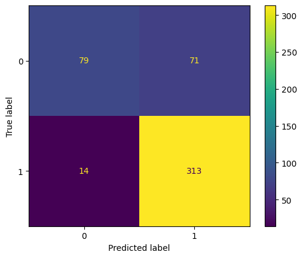

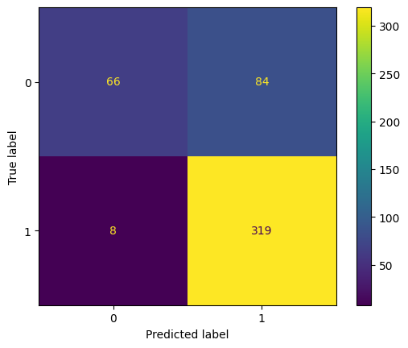

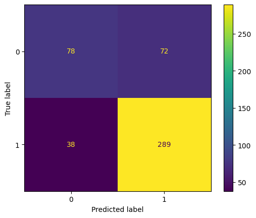

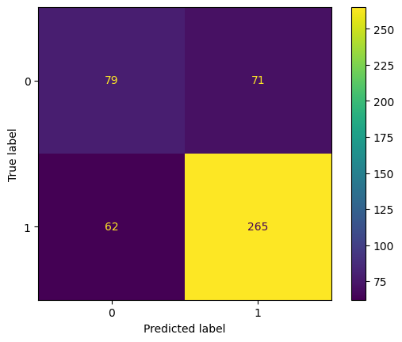

```python
best_model_label_encoded_sm_xgb = random_search_label_encoded_sm_xgb.best_estimator_
best_model_onehot_sm_xgb = random_search_onehot_sm_xgb.best_estimator_
best_model_onehot_xgb = random_search_onehot_xgb.best_estimator_
best_model_label_encoded_xgb = random_search_label_encoded_xgb.best_estimator_


Y_test_onehot_predict_xgb = best_model_onehot_xgb.predict(X_test_onehot)
Y_test_label_encoded_predict_xgb = best_model_label_encoded_xgb.predict(X_test_label_encoded)
Y_test_onehot_predict_sm_xgb = best_model_onehot_sm_xgb.predict(X_test_onehot)
Y_test_label_encoded_predict_sm_xgb = best_model_label_encoded_sm_xgb.predict(X_test_label_encoded)


ConfusionMatrixDisplay(confusion_matrix(Y_test_onehot, Y_test_onehot_predict_xgb)).plot()
ConfusionMatrixDisplay(confusion_matrix(Y_test_label_encoded, Y_test_label_encoded_predict_xgb)).plot()
ConfusionMatrixDisplay(confusion_matrix(Y_test_onehot, Y_test_onehot_predict_sm_xgb)).plot()
ConfusionMatrixDisplay(confusion_matrix(Y_test_label_encoded, Y_test_label_encoded_predict_sm_xgb)).plot()
```

```python
# with f1
print(classification_report(Y_test_onehot, Y_test_onehot_predict_xgb))
print(classification_report(Y_test_label_encoded, Y_test_label_encoded_predict_xgb))
print(classification_report(Y_test_onehot, Y_test_onehot_predict_sm_xgb))
print(classification_report(Y_test_label_encoded, Y_test_label_encoded_predict_sm_xgb))
```

```
              precision    recall  f1-score   support

           0       0.85      0.53      0.65       150
           1       0.82      0.96      0.88       327

    accuracy                           0.82       477
   macro avg       0.83      0.74      0.77       477
weighted avg       0.83      0.82      0.81       477

              precision    recall  f1-score   support

           0       0.89      0.44      0.59       150
           1       0.79      0.98      0.87       327

    accuracy                           0.81       477
   macro avg       0.84      0.71      0.73       477
weighted avg       0.82      0.81      0.78       477

              precision    recall  f1-score   support

           0       0.67      0.52      0.59       150
           1       0.80      0.88      0.84       327

    accuracy                           0.77       477
   macro avg       0.74      0.70      0.71       477
weighted avg       0.76      0.77      0.76       477

              precision    recall  f1-score   support

           0       0.56      0.53      0.54       150
           1       0.79      0.81      0.80       327

    accuracy                           0.72       477
   macro avg       0.67      0.67      0.67       477
weighted avg       0.72      0.72      0.72       477
```

# 7.Actionable insights and Recommendations

**Final model**:

Random Forest(Bagging)

**Best parameters:**

- n_estimators = 100 (number of trees in the forest)
- min_samples_split = 20 (minimum samples required to split an internal node)
- min_samples_leaf = 1 (minimum number of samples required in a leaf node)
- max_features = 'sqrt' (number of features to consider for best split)
- max_depth = None (no limit on tree depth, allowing full learning)
- criterion = 'entropy' (splitting criterion based on information gain)

**Classification Report Analysis:**

Train Accuracy: 0.9070

Test Accuracy: 0.7736

Train Precision: 0.9065

Test Precision: 0.8308

Train Recall: 0.9070

Test Recall: 0.8410

Train F1-score: 0.9066

Test F1-score: 0.8359

The classification report provides insights into model performance for predicting driver attrition:

- Class 1 (Attrition) has a high recall (0.84), meaning the model effectively identifies drivers likely to leave.
- Class 0 (Retention) has lower recall (0.63), indicating some drivers who stay are misclassified as leavers.
- Overall accuracy (0.77) suggests a reliable model but room for improvement.
- Macro avg (0.74 F1-score) shows balanced performance across both classes, but the model is slightly biased towards Class 1.

**Key Takeaway**

The model prioritizes identifying leavers well but can be fine-tuned to reduce misclassification of retained drivers (e.g., by adjusting the threshold)